# visualization2

Do Won Kim

2024-04-10

# 1 Data Description

```r
library(tidyverse)
library(ggplot2)
library(DT)
library(haven)
library(ggpubr)
library(cowplot)
library(ggthemes)
library(readr)
library(ggExtra)
library(scales)
library(Rmisc)
library(ggbeeswarm) # to make jitter plots
library(RColorBrewer) # for the colors
library(patchwork)
```

```r
# load raw data
df_w1 <- readRDS("~/Downloads/2023-095b_files/2023-095a_client_wave-1.rds")
df_w1_supp <- readRDS("~/Downloads/2023-095b_files/2023-095a_client_wave-1_supp.rds")
df_w2 <- readRDS("~/Downloads/2023-095b_files/2023-095b_client_wave-2.rds")

# bind wave 1 data + filter only Progress == 100
df_w1 = rbind(df_w1, df_w1_supp)
df_w1 |>
  select(-user_id) |>
  filter(Progress==100) -> df_w1

# invited users list (for merge)
Users_to_invite_Wave2 <- read_csv("Users_to_invite_Wave2.csv",
    col_types = cols(user_id = col_character()))
Users_to_invite_Wave2 |>
  select(user_id) |>
  mutate(userid = user_id) -> for_merge

# merged with invited user list
df_w2 |>
  merge(for_merge, by='userid') -> w2_users

# merged with invited user list
w2_users |>
  select(userid, user_id) |>
  merge(df_w1, by='userid') -> w1_users

# drop randomized_group == 'drop' from wave 2
w2_users |>
  filter(randomized_group != 'drop') |>
  filter(randomized_group != 'muting_treatment2_drop') |>
  select(userid, randomized_group) -> wave2_data

names(wave2_data) = c('user_id', 'randomized_group')
# 134 users without drop

# muted_accounts
muted_accounts <- read_csv("muted_accounts.csv",
    col_types = cols(user_id = col_character(),
        target_user_id = col_character()))

# exposure data
pre_hometimeline <- read_csv("pre_hometimeline.csv",
    col_types = cols(user_id = col_character(),
        target_user_id = col_character()))

pre_hometimeline |>
  mutate(tag = "pre_hometimeline") -> pre_hometimeline

post_hometimeline <- read_csv("post_hometimeline.csv",
    col_types = cols(user_id = col_character(),
        target_user_id = col_character()))

post_hometimeline |>
  mutate(tag = "post_hometimeline") -> post_hometimeline

# engagement data
pre_engagement <- read_csv("pre_engagement.csv",
    col_types = cols(user_id = col_character(),
        target_user_id = col_character()))

pre_engagement |>
  mutate(tag = "pre_engagement") -> pre_engagement

post_engagement <- read_csv("post_engagement.csv",
    col_types = cols(user_id = col_character(),
        target_user_id = col_character()))

post_engagement |>
  mutate(tag = "post_engagement") -> post_engagement

# likes data
pre_likes <- read_csv("pre_likes.csv",
    col_types = cols(user_id = col_character(),
        target_user_id = col_character()))
names(pre_likes)[3] = "type"
pre_likes |>
  mutate(tag = "pre_likes") -> pre_likes

post_likes <- read_csv("post_likes.csv",
    col_types = cols(user_id = col_character(),
        target_user_id = col_character()))
names(post_likes)[3] = "type"

post_likes |>
  mutate(tag = "post_likes") -> post_likes

# truncated list
updated_inventory <- read_csv("updated_inventory.csv",
    col_types = cols_only(target_user_id = col_character()))
reduced_inventory = updated_inventory[c(1:489),]
```

```r
wave2_data |> merge(pre_engagement, by='user_id') -> this_1
wave2_data |> merge(post_engagement, by='user_id') -> this_2
wave2_data |> merge(pre_hometimeline, by='user_id') -> this_3
wave2_data |> merge(post_hometimeline, by='user_id') -> this_4
wave2_data |> merge(pre_likes, by='user_id') -> this_5
wave2_data |> merge(post_likes, by='user_id') -> this_6
rbind(this_1, this_2, this_3, this_4, this_5, this_6) -> test
# 2 users (1150557764910866432,2611894363) dropped since they don't have any engagement/exposure data
# test: unique users N=132
```

```r
reduced_inventory |> mutate(reduced = "yes") -> reduced_inventory
muted_accounts |> mutate(muted = "yes") -> muted_accounts

test |>
  merge(muted_accounts, by = c('user_id', 'target_user_id'), all.x = TRUE) |>
  mutate(
    muted = ifelse(is.na(muted), "no", muted)
  ) |>
  merge(reduced_inventory, by='target_user_id', all.x = TRUE) |>
  mutate(
    reduced = ifelse(is.na(reduced), "no", reduced)
  ) |>
  relocate(c(user_id, randomized_group)) -> this_is_full_data
```

```r
# count_engagement.csv
count_engagement <- read_csv("count_engagement.csv",
    col_types = cols(user_id = col_character()))

this_is_full_data |>
  merge(count_engagement, by=c('user_id','tag') ,all.x=TRUE) -> this_is_final_data

this_is_final_data |>
  filter(user_id!="1165632418449186822" & user_id !='1590859787029213186' & user_id != '975899686774165504' & user_id != '375334044' & user_id != '1354968197078900743') -> this_is_final_data
```

Data: `this_is_final_data`

N=132 (control: 47, media_literacy: 41, muting_treatment1: 43, muting_treatment2: 1)

Let’s remove those accounts that blocked the study account or are locked/suspended (we could not collect post-treatment data).

**✅ N=127 (control: 46, media_literacy: 39, muting_treatment1: 41)**

(user level)

(user-LQ account dyad level)

- `target_user_id`: LQ accounts’ Twitter IDs (found in home timeline or engagement data)
- `type`: Type of tweets related to LQ sources
  - `direct`: Direct tweets mentioning LQ sources; Direct tweets produced by LQ sources for likes
  - `indirect`: (only for likes) likes of tweets that mention LQ sources (@) or their URLs
  - `replied`: Reply tweets to LQ sources
  - `retweeted`: Any retweets of LQ tweets
  - `quoted`: Any quote tweets of LQ tweets
- `muted` : Whether the LQ source is muted (“yes”) or not (“no”)
- `reduced` : Whether the LQ source is included in the reduced list (“yes”) or not (“no”)

```r
this_is_final_data |>
  relocate(user_id, randomized_group, tag, count) |>
  datatable(filter='top')
```

|  | user_id | randomized_group | tag | count | target_user_id | type | muted | reduced |
| --- | --- | --- | --- | --- | --- | --- | --- | --- |
| 1 | 1040039078270517248 | media_literacy | post_hometimeline | 399 | 537709549 | retweeted | no | no |
| 2 | 1040039078270517248 | media_literacy | post_hometimeline | 399 | 147821538 | direct | no | yes |
| 3 | 1040039078270517248 | media_literacy | post_hometimeline | 399 | 537709549 | retweeted | no | no |
| 4 | 1040039078270517248 | media_literacy | post_hometimeline | 399 | 1446932149148344320 | direct | yes | yes |
| 5 | 1040039078270517248 | media_literacy | post_hometimeline | 399 | 1446932149148344320 | direct | yes | yes |
| 6 | 1040039078270517248 | media_literacy | post_hometimeline | 399 | 1446932149148344320 | direct | yes | yes |
| 7 | 1040039078270517248 | media_literacy | post_hometimeline | 399 | 36266589 | retweeted | no | no |
| 8 | 1040039078270517248 | media_literacy | post_hometimeline | 399 | 1446932149148344320 | direct | yes | yes |
| 9 | 1040039078270517248 | media_literacy | post_hometimeline | 399 | 1446932149148344320 | direct | yes | yes |
| 10 | 1040039078270517248 | media_literacy | post_hometimeline | 399 | 1446932149148344320 | direct | yes | yes |

[output cut: 11230 more lines]

# 2 **Task 1. First-Stage Check**

> For the mute group, post-treatment engagements/exposure to “muted” accounts vs. For the control group, post-treatment engagements/exposure to hypothetically “muted” accounts (accounts that would have been muted if they were assigned to the muting group)
1. For `Muting` group: Post-treatment engagements with/exposure to/likes of “muted” sources
2. For `Control` group (control + media_literacy): Post-treatment engagements with/exposure to/likes of “hypothetically muted” sources

(This removed those users who have engagements/exposures exclusively to the LQ accounts that are “not” muted either in real or hypothetically, resulting in 95 unique users for the task 1.)

FYI) **For muted accounts that you follow:**

- Replies and mentions by the muted account will still appear in your Notifications tab.
- posts from a muted account – posted before the account was muted – will be removed from your Home timeline.
- When you click or tap into a conversation, replies from muted accounts will be visible.

```r
this_is_final_data |>
  mutate(
    group = ifelse(randomized_group=="media_literacy" |
                     randomized_group=='control', "Control", "Muting")
  ) |>
  mutate(flag = ifelse(
    group == "Control" & muted == "yes", "include",
    # For Control group, only include cases where muted == "yes"
    ifelse(
      group == "Muting" & muted == "yes", "include",
      # For Muting group, only include cases where muted == "yes"
      "drop"
      # The rest of the cases (muted == "no"), drop
    )
  )) |>
  filter(flag == "include") |> select(!flag) -> test_again

test_again |>
  select(user_id, tag, randomized_group, count) |>
  group_by(user_id, tag) |>
  count() |> ungroup() -> test_for_muted

# test_for_muted - if there are no categories (tag), freq == 0
test_for_muted |>
  select(user_id, tag, freq) |>
  pivot_wider(names_from=tag, values_from=freq) |>
  mutate_if(is.numeric , replace_na, replace = 0) |>
  relocate(user_id,
           pre_hometimeline, post_hometimeline,
           pre_engagement, post_engagement,
           pre_likes, post_likes) -> test_for_muted_wider

test_for_muted_wider |>
  select(user_id, pre_hometimeline:post_likes) |>
  pivot_longer(cols=pre_hometimeline:post_likes,
               names_to = "tag",
               values_to = "n") -> test_for_muted_longer
test_again |>
  select(user_id, tag, count) |>
  unique() |>
  merge(test_for_muted_longer, by=c("user_id", "tag"), all=TRUE) |>
  mutate_if(is.numeric , replace_na, replace = 0) -> test_for_muted_longer2

test_again |> select(user_id, tag, randomized_group) |> unique() -> for_merge_muted_1
for_merge_muted_1 |>
  select(user_id, randomized_group) |>
  unique() -> for_merge_muted_2

test_for_muted_longer2 |>
  merge(for_merge_muted_1, by = c('user_id', 'tag'), all.x = T) |>
  select(user_id, tag, count, n) |>
  merge(for_merge_muted_2, by = "user_id") |>
  mutate(group = ifelse(randomized_group == "control" |
                          randomized_group == "media_literacy",
                        "Control", "Muting")) -> test_for_muted_longer3

# backup
df_plot_muted = test_for_muted_longer3
```

## 2.1 Plot 1. Post-treatment engagement

Post-treatment engagement (tweets, re-tweets, quotes, replies) with (hypothetically) muted accounts between `control` vs. `muting`

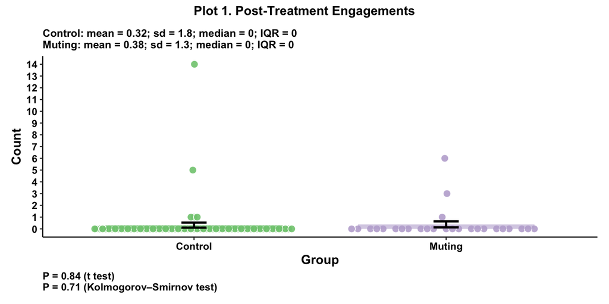

```r
df_plot_muted |>
  mutate(rate = (n/count)*100) |>
  mutate_if(is.numeric , replace_na, replace = 0) |>
  mutate(rate = round(rate,1)) |>
  filter(tag == 'post_engagement') |> # tag == 'post_engagement' filter
  select(user_id, group, n, rate) -> df_post_engagement

df_post_engagement |>
  filter(group == "Control") |>
  select(n) |>
  as.vector() |>
  unlist() |>
  as.integer() -> group1

df_post_engagement |>
  filter(group == "Muting") |>
  select(n) |>
  as.vector() |>
  unlist() |>
  as.integer() -> group2

df_post_engagement |>
  ggplot(aes(x = group, y = n)) +
  ggbeeswarm::geom_quasirandom(
    shape = 21, color = "white",
    alpha = 0.9, size = 3,
    aes(fill = group)
  ) +
  geom_bar(stat = "summary", fun = mean, width = 0.7, alpha = 0.6, aes(fill = group)) +
  stat_summary(geom = "errorbar", fun.data = "mean_se", width = 0.1, linewidth = 1) +
  scale_fill_manual(values = brewer.pal(8, "Accent")[1:2]) +
  scale_y_continuous(n.breaks=15) +
  labs(x = "Group",
       y = "Count",
       caption = paste0("P = ",
                        signif(t.test(group1, group2)$p.value, 2),
                        " (t test)", "\n",
                        "P = ",
                        signif(ks.test(group1, group2)$p.value, 2),
                        " (Kolmogorov–Smirnov test)")) +
  theme_classic() +
  theme(
    text = element_text(size = 12, face = "bold", color = "black"),
    axis.text = element_text(color = "black"),
    legend.position = "none",
    plot.title = element_text(size = 10),
    plot.caption = element_text(hjust = 0)
  ) +
  ggtitle(
        paste0(
            "Control: mean = ", signif(mean(group1), 2),
            "; sd = ", signif(sd(group1), 2), "; median = ", signif(median(group1), 2),
            "; IQR = ", signif(IQR(group1), 2), "\n",
            "Muting: mean = ", signif(mean(group2), 2),
            "; sd = ", signif(sd(group2), 2),
            "; median = ", signif(median(group2), 2),
            "; IQR = ", signif(IQR(group2), 2)
        ))  -> bar_post_engagement

df_post_engagement |>
  ggplot(aes(x = group, y = n)) +
  geom_bar(stat = "summary", fun = mean, width = 0.7, alpha = 0.8, aes(fill = group)) +
  stat_summary(geom = "errorbar", fun.data = "mean_se", width = 0.1, linewidth = 1) +
  ggbeeswarm::geom_quasirandom(
    shape = 21, color = "white",
    alpha = 0.8, size = 3,
    aes(fill = group)) +
  scale_fill_manual(values = brewer.pal(8, "Accent")[1:2]) +
  scale_y_sqrt(n.breaks=15) +
  labs(x = "Group",
       y = "Count (sqrt scale)",
       caption = paste0("P = ",
                        signif(t.test(group1, group2)$p.value, 2),
                        " (t test)", "\n",
                        "P = ",
                        signif(ks.test(group1, group2)$p.value, 2),
                        " (Kolmogorov–Smirnov test)")) +
    theme_classic() +
    theme(
        text = element_text(size = 12, face = "bold", color = "black"),
        axis.text = element_text(color = "black"),
        legend.position = "none",
        plot.title = element_text(size = 10),
        plot.caption = element_text(hjust = 0)
    ) +
    ggtitle(
        paste0(
            "Control: mean = ", signif(mean(group1), 2),
            "; sd = ", signif(sd(group1), 2), "; median = ", signif(median(group1), 2),
            "; IQR = ", signif(IQR(group1), 2), "\n",
            "Muting: mean = ", signif(mean(group2), 2),
            "; sd = ", signif(sd(group2), 2),
            "; median = ", signif(median(group2), 2),
            "; IQR = ", signif(IQR(group2), 2)
        )) -> sqrt_post_engagement


plot_post_engage <- bar_post_engagement +
  plot_annotation('Plot 1. Post-Treatment Engagements',
                  theme=theme(plot.title=element_text(size = 12,
                                                      face = "bold",
                                                      color = "black",
                                                      hjust=0.5)))
plot_post_engage
```

```r
ggsave("../Results/plot1_muted.png", height = 5, width = 10)
```

The y-axis (`Count`) indicates the number of tweets related to LQ sources that one engaged with (=engagement). These include direct mentions of LQ accounts, replies, retweets, and quote tweets of tweets created by LQ accounts, as well as direct URLs to these LQ domains.

Group: `Control` includes control group and media literacy group, while `Muting` includes muting treatment groups. For `Muting` group, only engagements with those LQ accounts that are *muted* are counted. Note that in pilot study, we muted 70% of the truncated list (truncated list: n=489).

Hence, Plot 1 allows us to compare the post-treatment engagements with (hypothetically) muted LQ accounts between `Control` and `Muting` groups.

For most participants, we see low levels of engagements with LQ accounts with a few outliers (active ones). Given this highly skewed distribution, and to be careful with comparison, I overlayed the same quantities but with different ways of visualizing them.

1. Bar plot
   - Comparison: mean
   - Error bars indicate SEs of the mean
   - t-test statistics (p-value presented)
2. Dot plot
   - Comparison: distribution
   - K-S test (nonparametric)

## 2.2 Plot 2. Post-treatment exposure

Post-treatment exposure between `control` vs. `muting` (for muted accounts)

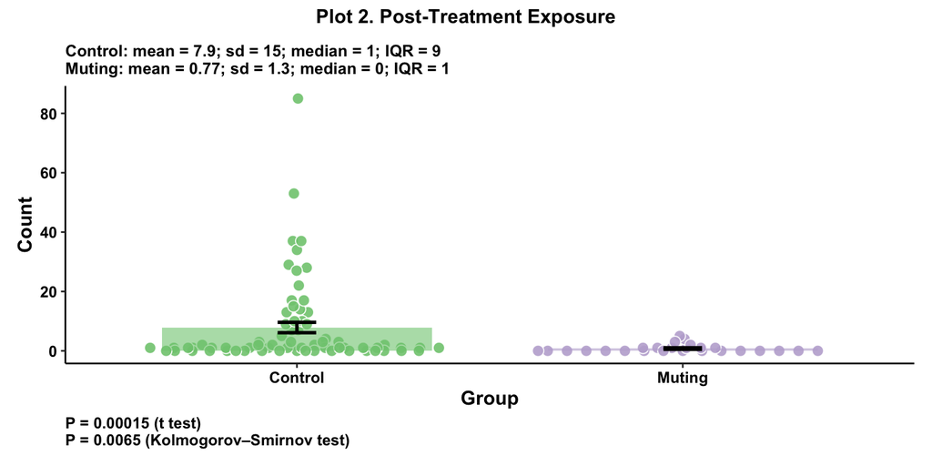

```r
df_plot_muted |>
  filter(tag == "post_hometimeline") |> # tag == 'post_hometimeline' filter
  select(user_id, group, n) -> df_post_hometimeline

df_post_hometimeline |>
  filter(group == "Control") |>
  select(n) |>
  as.vector() |>
  unlist() |>
  as.integer() -> group1

df_post_hometimeline |>
  filter(group == "Muting") |>
  select(n) |>
  as.vector() |>
  unlist() |>
  as.integer() -> group2

df_post_hometimeline |>
  ggplot(aes(x = group, y = n)) +
  ggbeeswarm::geom_quasirandom(
    shape = 21, color = "white",
    alpha = 0.9, size = 3,
    aes(fill = group)
  ) +
  geom_bar(stat = "summary", fun = mean, width = 0.7, alpha = 0.6, aes(fill = group)) +
  stat_summary(geom = "errorbar", fun.data = "mean_se", width = 0.1, linewidth = 1) +
  scale_fill_manual(values = brewer.pal(8, "Accent")[1:2]) +
  labs(x = "Group",
       y = "Count",
      caption = paste0("P = ",
                        signif(t.test(group1, group2)$p.value, 2),
                        " (t test)", "\n",
                        "P = ",
                        signif(ks.test(group1, group2)$p.value, 2),
                        " (Kolmogorov–Smirnov test)")) +
  theme_classic() +
  theme(
    text = element_text(size = 12, face = "bold", color = "black"),
    axis.text = element_text(color = "black"),
    legend.position = "none",
    plot.title = element_text(size = 10),
    plot.caption = element_text(hjust = 0)
  ) +
  ggtitle(
    paste0(
      "Control: mean = ", signif(mean(group1), 2),
      "; sd = ", signif(sd(group1), 2), "; median = ", signif(median(group1), 2),
      "; IQR = ", signif(IQR(group1), 2), "\n",
      "Muting: mean = ", signif(mean(group2), 2),
      "; sd = ", signif(sd(group2), 2),
      "; median = ", signif(median(group2), 2),
      "; IQR = ", signif(IQR(group2), 2)
      ))-> bar_post_hometimeline

plot_post_exposure <- bar_post_hometimeline +
  plot_annotation('Plot 2. Post-Treatment Exposure',
                  theme=theme(plot.title=element_text(size = 12,
                                                      face = "bold",
                                                      color = "black",
                                                      hjust=0.5)))
plot_post_exposure
```

```r
ggsave("../Results/plot2_muted.png", height = 5, width = 10)
```

The y-axis (`Count`) indicates the number of tweets from LQ sources (that are muted) found in one’s home timeline (=exposure).

Hence, Plot 2 allows us to compare the post-treatment exposures to (hypothetically) muted LQ accounts between `Control` and `Muting` groups.

## 2.3 Plot 3. Post-treatment Likes

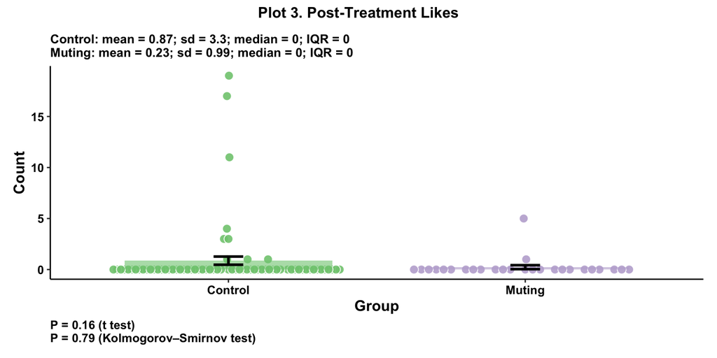

```r
df_plot_muted |>
  filter(tag == "post_likes") |> # tag == 'post_likes' filter
  select(user_id, group, n) -> df_post_likes

df_post_likes |>
  filter(group == "Control") |>
  select(n) |>
  as.vector() |>
  unlist() |>
  as.integer() -> group1

df_post_likes |>
  filter(group == "Muting") |>
  select(n) |>
  as.vector() |>
  unlist() |>
  as.integer() -> group2

df_post_likes |>
  ggplot(aes(x = group, y = n)) +
  ggbeeswarm::geom_quasirandom(
    shape = 21, color = "white",
    alpha = 0.9, size = 3,
    aes(fill = group)
  ) +
  geom_bar(stat = "summary", fun = mean, width = 0.7, alpha = 0.6, aes(fill = group)) +
  stat_summary(geom = "errorbar", fun.data = "mean_se", width = 0.1, linewidth = 1) +
  scale_fill_manual(values = brewer.pal(8, "Accent")[1:2]) +
  labs(x = "Group",
       y = "Count",
      caption = paste0("P = ",
                        signif(t.test(group1, group2)$p.value, 2),
                        " (t test)", "\n",
                        "P = ",
                        signif(ks.test(group1, group2)$p.value, 2),
                        " (Kolmogorov–Smirnov test)")) +
  theme_classic() +
  theme(
    text = element_text(size = 12, face = "bold", color = "black"),
    axis.text = element_text(color = "black"),
    legend.position = "none",
    plot.title = element_text(size = 10),
    plot.caption = element_text(hjust = 0)
  ) +
  ggtitle(
    paste0(
      "Control: mean = ", signif(mean(group1), 2),
      "; sd = ", signif(sd(group1), 2), "; median = ", signif(median(group1), 2),
      "; IQR = ", signif(IQR(group1), 2), "\n",
      "Muting: mean = ", signif(mean(group2), 2),
      "; sd = ", signif(sd(group2), 2),
      "; median = ", signif(median(group2), 2),
      "; IQR = ", signif(IQR(group2), 2)
      ))-> bar_post_likes

plot_post_likes <- bar_post_likes +
  plot_annotation('Plot 3. Post-Treatment Likes',
                  theme=theme(plot.title=element_text(size = 12,
                                                      face = "bold",
                                                      color = "black",
                                                      hjust=0.5)))
plot_post_likes
```

```r
ggsave("../Results/plot3_muted.png", height = 5, width = 10)
```

The y-axis (`Count`) indicates the number of likes to tweets related to LQ sources that are muted (=likes).

Hence, Plot 3 allows us to compare the post-treatment likes to (hypothetically) muted LQ accounts between `Control` and `Muting` groups.

### 2.3.1 Takeaways

1. Overall, engagement levels are very low (only handful of participants actively engaging with LQ sources). This might resulted in minimal first-stage effect.
2. For post-treatment home timeline exposure, we do see some meaningful differences between control vs. muting groups.

## 2.4 Plot 4. Pre-treatment engagement

Pre-treatment engagement between `control` vs. `muting` (for muted accounts)

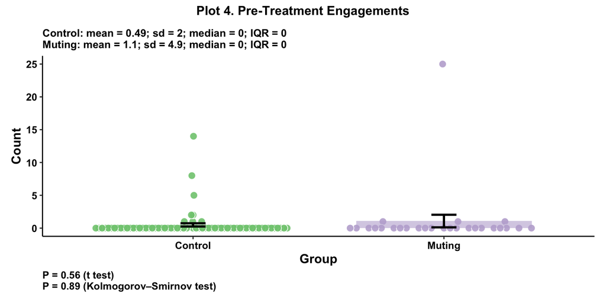

```r
df_plot_muted |>
  filter(tag == "pre_engagement") |>
  select(user_id, group, n) -> df_pre_engagement

df_pre_engagement |>
  filter(group == "Control") |>
  select(n) |>
  as.vector() |>
  unlist() |>
  as.integer() -> group1

df_pre_engagement |>
  filter(group == "Muting") |>
  select(n) |>
  as.vector() |>
  unlist() |>
  as.integer() -> group2


df_pre_engagement |>
  ggplot(aes(x = group, y = n)) +
  ggbeeswarm::geom_quasirandom(
    shape = 21, color = "white",
    alpha = 0.9, size = 3,
    aes(fill = group)
  ) +
  geom_bar(stat = "summary", fun = mean, width = 0.7, alpha = 0.6, aes(fill = group)) +
  stat_summary(geom = "errorbar", fun.data = "mean_se", width = 0.1, linewidth = 1) +
  scale_fill_manual(values = brewer.pal(8, "Accent")[1:2]) +
  labs(x = "Group",
       y = "Count",
      caption = paste0("P = ",
                        signif(t.test(group1, group2)$p.value, 2),
                        " (t test)", "\n",
                        "P = ",
                        signif(ks.test(group1, group2)$p.value, 2),
                        " (Kolmogorov–Smirnov test)")) +
  theme_classic() +
  theme(
    text = element_text(size = 12, face = "bold", color = "black"),
    axis.text = element_text(color = "black"),
    legend.position = "none",
    plot.title = element_text(size = 10),
    plot.caption = element_text(hjust = 0)
  ) +
  ggtitle(
    paste0(
      "Control: mean = ", signif(mean(group1), 2),
      "; sd = ", signif(sd(group1), 2), "; median = ", signif(median(group1), 2),
      "; IQR = ", signif(IQR(group1), 2), "\n",
      "Muting: mean = ", signif(mean(group2), 2),
      "; sd = ", signif(sd(group2), 2),
      "; median = ", signif(median(group2), 2),
      "; IQR = ", signif(IQR(group2), 2)
      ))-> bar_pre_engagement

bar_pre_engagement + plot_annotation('Plot 4. Pre-Treatment Engagements',
                        theme=theme(plot.title=element_text(size = 12,
                                                            face = "bold",
                                                            color = "black",
                                                            hjust=0.5)))
```

```r
ggsave("../Results/plot4_muted.png", height = 5, width = 10)
```

## 2.5 Plot 5. Pre-treatment exposure

Pre-treatment exposure between `control` vs. `muting` (for muted accounts)

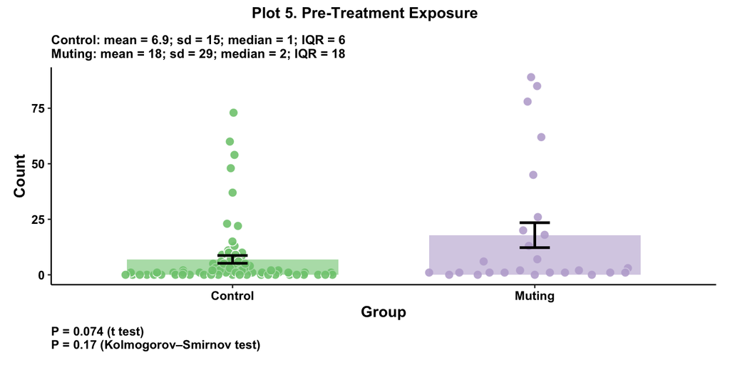

```r
# Use df_plot_unmuted
df_plot_muted |>
  filter(tag == "pre_hometimeline") |> # tag == 'post_hometimeline' filter
  select(user_id, group, n) -> df_pre_hometimeline

df_pre_hometimeline |>
  filter(group == "Control") |>
  select(n) |>
  as.vector() |>
  unlist() |>
  as.integer() -> group1

df_pre_hometimeline |>
  filter(group == "Muting") |>
  select(n) |>
  as.vector() |>
  unlist() |>
  as.integer() -> group2


df_pre_hometimeline |>
  ggplot(aes(x = group, y = n)) +
  ggbeeswarm::geom_quasirandom(
    shape = 21, color = "white",
    alpha = 0.9, size = 3,
    aes(fill = group)
  ) +
  geom_bar(stat = "summary", fun = mean, width = 0.7, alpha = 0.6, aes(fill = group)) +
  stat_summary(geom = "errorbar", fun.data = "mean_se", width = 0.1, linewidth = 1) +
  scale_fill_manual(values = brewer.pal(8, "Accent")[1:2]) +
  labs(x = "Group",
       y = "Count",
      caption = paste0("P = ",
                        signif(t.test(group1, group2)$p.value, 2),
                        " (t test)", "\n",
                        "P = ",
                        signif(ks.test(group1, group2)$p.value, 2),
                        " (Kolmogorov–Smirnov test)")) +
  theme_classic() +
  theme(
    text = element_text(size = 12, face = "bold", color = "black"),
    axis.text = element_text(color = "black"),
    legend.position = "none",
    plot.title = element_text(size = 10),
    plot.caption = element_text(hjust = 0)
  ) +
  ggtitle(
    paste0(
      "Control: mean = ", signif(mean(group1), 2),
      "; sd = ", signif(sd(group1), 2), "; median = ", signif(median(group1), 2),
      "; IQR = ", signif(IQR(group1), 2), "\n",
      "Muting: mean = ", signif(mean(group2), 2),
      "; sd = ", signif(sd(group2), 2),
      "; median = ", signif(median(group2), 2),
      "; IQR = ", signif(IQR(group2), 2)
      ))-> bar_pre_exposure

bar_pre_exposure + plot_annotation('Plot 5. Pre-Treatment Exposure',
                        theme=theme(plot.title=element_text(size = 12,
                                                            face = "bold",
                                                            color = "black",
                                                            hjust=0.5)))
```

```r
ggsave("../Results/plot5_muted.png", height = 5, width = 10)
```

## 2.6 Plot 6. Pre-treatment likes

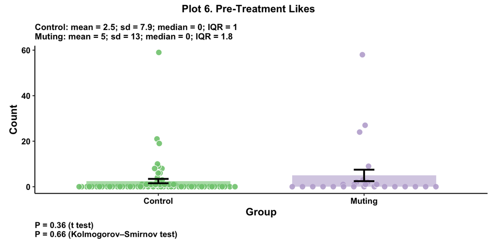

```r
# Use df_plot_unmuted
df_plot_muted |>
  filter(tag == "pre_likes") |>
  select(user_id, group, n) -> df_pre_likes

df_pre_likes |>
  filter(group == "Control") |>
  select(n) |>
  as.vector() |>
  unlist() |>
  as.integer() -> group1

df_pre_likes |>
  filter(group == "Muting") |>
  select(n) |>
  as.vector() |>
  unlist() |>
  as.integer() -> group2


df_pre_likes |>
  ggplot(aes(x = group, y = n)) +
  ggbeeswarm::geom_quasirandom(
    shape = 21, color = "white",
    alpha = 0.9, size = 3,
    aes(fill = group)
  ) +
  geom_bar(stat = "summary", fun = mean, width = 0.7, alpha = 0.6, aes(fill = group)) +
  stat_summary(geom = "errorbar", fun.data = "mean_se", width = 0.1, linewidth = 1) +
  scale_fill_manual(values = brewer.pal(8, "Accent")[1:2]) +
  labs(x = "Group",
       y = "Count",
      caption = paste0("P = ",
                        signif(t.test(group1, group2)$p.value, 2),
                        " (t test)", "\n",
                        "P = ",
                        signif(ks.test(group1, group2)$p.value, 2),
                        " (Kolmogorov–Smirnov test)")) +
  theme_classic() +
  theme(
    text = element_text(size = 12, face = "bold", color = "black"),
    axis.text = element_text(color = "black"),
    legend.position = "none",
    plot.title = element_text(size = 10),
    plot.caption = element_text(hjust = 0)
  ) +
  ggtitle(
    paste0(
      "Control: mean = ", signif(mean(group1), 2),
      "; sd = ", signif(sd(group1), 2), "; median = ", signif(median(group1), 2),
      "; IQR = ", signif(IQR(group1), 2), "\n",
      "Muting: mean = ", signif(mean(group2), 2),
      "; sd = ", signif(sd(group2), 2),
      "; median = ", signif(median(group2), 2),
      "; IQR = ", signif(IQR(group2), 2)
      ))-> bar_pre_likes

bar_pre_likes + plot_annotation('Plot 6. Pre-Treatment Likes',
                        theme=theme(plot.title=element_text(size = 12,
                                                            face = "bold",
                                                            color = "black",
                                                            hjust=0.5)))
```

```r
ggsave("../Results/plot6_muted.png", height = 5, width = 10)
```

### 2.6.1 Takeaways

In general, no differences between control vs. muting groups in pre-treatment engagements, exposure, and likes!

# 3 Note

1. About data collection
   - I collected post-treatment data on Mar 26, which is ~26 days after the start of Wave 2. Thus, the post-treatment data contains minimum 19 days ~ maximum 26 days post Wave 2, while pre-treatment data contains maximum 4 weeks.
     - FYI) For pre-treatment likes, the date can go way back.
   - Post-treatment data: Considering that muting took ~1 day or more, I filtered data with created_at >= Wave 2 session start time + 2 days, to make sure that I only include tweets from LQ sources after the muting job is done.